# Topic 3-02: Online GREAT analysis

Zuguang Gu z.gu@dkfz.de

2025-05-24

We first read the peaks (https://github.com/jokergoo/GSEAtraining/blob/master/inst/extdata/mm9_chipseq_peaks.bed) as a data frame.

```r
bed = read.table(system.file("extdata", "mm9_chipseq_peaks.bed", package = "GSEAtraining"))
head(bed)
```

```
##     V1       V2       V3
## 1 chr1 11017025 11017401
## 2 chr1 11734825 11735326
## 3 chr1 12605475 12606176
## 4 chr1 12680375 12681376
## 5 chr1 13416275 13416776
## 6 chr1 13850975 13851726
```

```r
dim(bed)
```

```
## [1] 2105    3
```

## Directly on the GREAT website

URL: https://great.stanford.edu/great/public/html/index.php

## Online GREAT analysis

Use `submitGreatJob()` to submit the regions to the GREAT web server. By default the species is human (hg19), so here we need to manually set the `species` argument.

Entering the object `job` prints the summary of the job.

```r
library(rGREAT)
job = submitGreatJob(bed, species = "mm9")
job
```

```
## Submit time: 2025-05-24 13:08:00
##   Note the results may only be avaiable on GREAT server for 24 hours.
## Version: 4.0.4
## Genome: mm9
## Inputs: 2105 regions
## Mode: Basal plus extension
##   Proximal: 5 kb upstream, 1 kb downstream,
##   plus Distal: up to 1000 kb
## Include curated regulatory domains
##
## Enrichment tables for following ontologies have been downloaded:
##   None
```

There are several ontologies integrated in GREAT. The total ontologies can be get by:

```r
availableOntologies(job)
```

```
## [1] "GO Molecular Function"     "GO Biological Process"
## [3] "GO Cellular Component"     "Mouse Phenotype"
## [5] "Mouse Phenotype Single KO" "Human Phenotype"
## [7] "Ensembl Genes"
```

By default three GO ontologies are used. More ontologies can be set via the `ontology` argument in `getEnrichmentTables()`.

```r
tbl = getEnrichmentTables(job)
```

```
## The default enrichment table does not contain informatin of associated
## genes for each input region. You can set `download_by = 'tsv'` to
## download the complete table, but note only the top 500 regions can be
## retreived. See the following link:
##
## https://great-help.atlassian.net/wiki/spaces/GREAT/pages/655401/Export#Export-GlobalExport
##
## Except the additional gene-region association column if taking 'tsv' as
## the source of result, all other columns are the same if you choose
## 'json' (the default) as the source. Or you can try the local GREAT
## analysis with the function `great()`.
```

`tb` is a list of three tables and each table contains enrichment results for a GO ontology:

```r
names(tbl)
```

```
## [1] "GO Molecular Function" "GO Biological Process" "GO Cellular Component"
```

```r
head(tbl[["GO Biological Process"]])
```

```
##           ID                                      name Binom_Genome_Fraction
## 1 GO:0048522   positive regulation of cellular process             0.4215839
## 2 GO:0048518 positive regulation of biological process             0.4511084
## 3 GO:0007275        multicellular organism development             0.4524430
## 4 GO:0032502                     developmental process             0.4867658
## 5 GO:0048856          anatomical structure development             0.4680561
## 6 GO:0044767     single-organism developmental process             0.4846442
##   Binom_Expected Binom_Observed_Region_Hits Binom_Fold_Enrichment
## 1       887.4340                       1245              1.402921
## 2       949.5831                       1304              1.373234
## 3       952.3924                       1294              1.358684
## 4      1024.6420                       1361              1.328269
## 5       985.2581                       1322              1.341780
## 6      1020.1760                       1356              1.329182
##   Binom_Region_Set_Coverage Binom_Raw_PValue Binom_Adjp_BH Hyper_Total_Genes
```

[output cut: 27 more lines]

The volcano plot is -log10 p-values vs log2 fold enrichment:

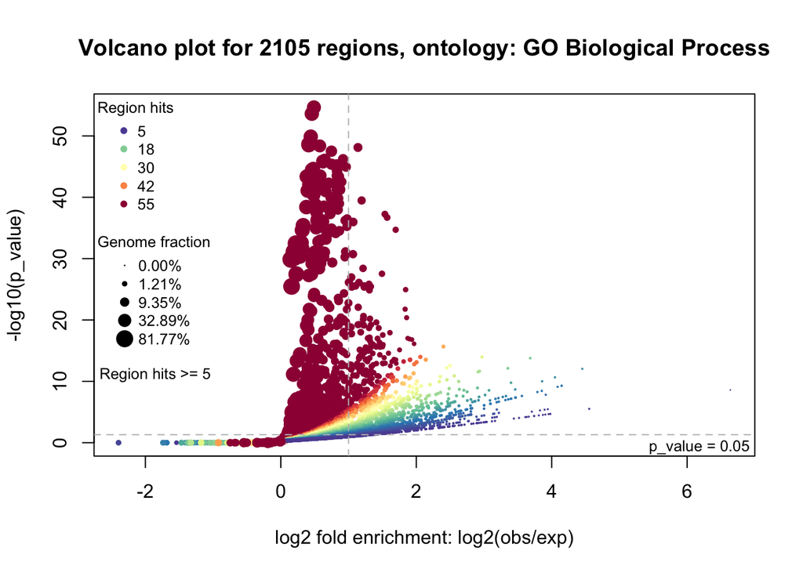

```r
plotVolcano(job, ontology = "GO Biological Process")
```

The global region-gene association plots:

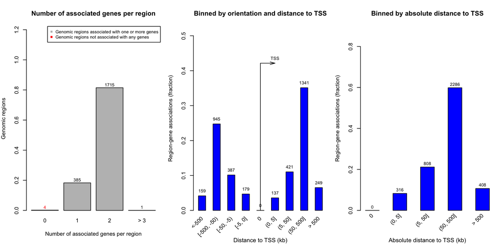

```r
plotRegionGeneAssociationGraphs(job)
```

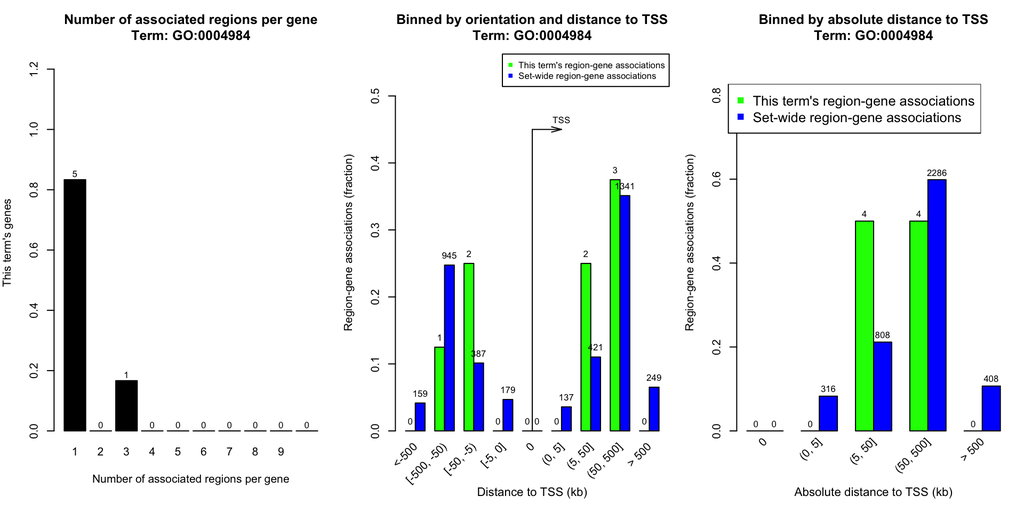

```r
plotRegionGeneAssociations(job, ontology = "GO Molecular Function",
    term_id = "GO:0004984")
```

The table of the associations between genes and regions.

```r
getRegionGeneAssociations(job, ontology = "GO Molecular Function",
    term_id = "GO:0004984")
```

```
## GRanges object with 6 ranges and 2 metadata columns:
##       seqnames              ranges strand | annotated_genes   dist_to_TSS
##          <Rle>           <IRanges>  <Rle> | <CharacterList> <IntegerList>
##   [1]     chr4   43851550-43851876      * | Olfr159,Olfr155 -67832,-12724
##   [2]     chr4   58682625-58684451      * |         Olfr267        115056
##   [3]     chr4   58690550-58691401      * |         Olfr267        107619
##   [4]     chr4   58735575-58736251      * |         Olfr267         62681
##   [5]     chr4 118315550-118316051      * |          Olfr62        -22324
##   [6]     chr7 115940725-115941576      * | Olfr514,Olfr513   28361,42778
##   -------
##   seqinfo: 2 sequences from an unspecified genome; no seqlengths
```

Try the shiny app:

```r
shinyReport(job)
```

## Practice

#### Practice 1

Perform GREAT analysis on the GREAT website with a list of TFBS from UCSC table browser:

```
clade: Mammal
genome: Human
assembly: GRCh37/hg19
group: Regulation
track: ENCODE 3 TFBS
table: 22Rv1 ZFX (encTfChipRkENCFF445OFX)
```

In the “output format” field, select “BED - browser extensible data”, then click the button “get output”. In the next page, click the button “get BED”.

#### Practice 2

Download the regions in practice 1 and perform online GREAT analysis with the **rGREAT** package.